# xwMOOC 모형

피처 공학 - 변수선택 자동화

# 1 Feature 선택 자동화 [^1]

변수선택 자동화를 위해서 “재귀 변수 제거법 (Recursive Feature Elimination)”, “보루타 알고리즘 (Boruta Algorithm)”을 살펴본다.

## 1.1 데이터셋 - 미군 신체측정

[미군 신체측정 데이터셋(Anthropometric Survey of US Army Personnel, ANSUR 2)](http://www.openlab.psu.edu/ansur2/)은 2012년 내부에 공개되었고 2017년에 대중에 공개되었다. 총 6,000명 군인(남자 4,082, 여자 1,986)에 대한 측정정보를 담고 있다.

```r
library(tidyverse)
male_dat <- read_csv("http://tools.openlab.psu.edu/publicData/ANSUR_II_MALE_Public.csv")
female_dat <- read_csv("http://tools.openlab.psu.edu/publicData/ANSUR_II_FEMALE_Public.csv")

soldier_dat <- bind_rows(male_dat, female_dat)

soldier_dat %>% write_rds("data/soldier_dat.rds")
```

다운로드 받은 남녀 데이터를 결합하여 남자군인, 여자군인을 분류하는데 사용되는 `X` 설계행렬을 추출한다.

```r
soldier_dat <- read_rds("data/soldier_dat.rds") %>%
  sample_frac(0.1)

X_df <- soldier_dat %>%
  select(-c("subjectid","SubjectId", "Gender", "Date", "Installation",  "Component", "Branch", "PrimaryMOS", "SubjectsBirthLocation",  "SubjectNumericRace", "Ethnicity", "DODRace", "Heightin", "Weightlbs")) %>%
  mutate(WritingPreference = as.factor(WritingPreference))

y_df <- soldier_dat %>%
  select(gender = Gender) %>%
  mutate(gender = factor(gender, levels = c("Female", "Male")))

Xy_df <- bind_cols(y_df, X_df)
```

# 2 변수 선택 - 보루타 알고리즘 [^2] [^3]

보루타 알고리즘을 통해 변수를 선택할 수 있다. 변수선택에는 크게 다음과 같은 세가지 방식이 존재한다.

- 필터 방법(Filter Method): 데이터 전처리 단계에서 상관계수, 카이제곱 검정, 분산분석, 피셔 점수 등을 사용해서 전처리 단계에서 기계학습 알고리즘과 무관하게 추출해낸다.
- 랩퍼 방법(Wrapper Method): 변수의 일부를 예측모형에 적합시켜 변수를 선택하는 방법으로 전진 선택(forward seleciton), 후진 선택(backward selection) 등을 들 수 있다.
- 내재 방법(Embedded Method): 라쏘 회귀(LASSO regression)와 같이 자체 변수 선택 방법을 내재하고 있는 알고리즘을 통해 변수를 선택한다.

보루타 알고리즘은 Random Forest에 기반한 변수 선택방법으로 Z값을 활용한다는 점이 다른 기존 변수방법과 비교하여 차이가 난다.

속도를 위해서 전체 변수를 모두 사용하는 대신에 앞에서부터 30개만 뽑아 보루타 변수선택 모형을 생성시킨다.

```r
library(Boruta)

Xy_boruta <- Boruta(gender ~ ., data = Xy_df[, 1:31], doTrace = 2, maxRuns = 500)

print(Xy_boruta)
```

```
Boruta performed 77 iterations in 12.1455 secs.
 29 attributes confirmed important:
abdominalextensiondepthsitting, acromialheight,
acromionradialelength, anklecircumference, axillaheight and 24
more;
 1 attributes confirmed unimportant:
crotchlengthposterioromphalion;
```

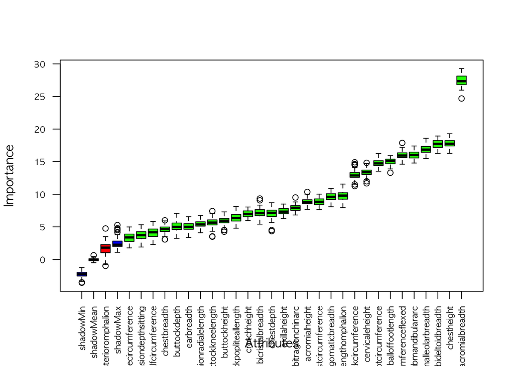

```r
plot(Xy_boruta, las = 2, cex.axis = 0.7)
```

```r
attStats(Xy_boruta) %>%
  rownames_to_column(var="variable") %>%
  arrange(desc(medianImp)) %>%
  DT::datatable()
```

|  | variable | meanImp | medianImp | minImp | maxImp | normHits | decision |
| --- | --- | --- | --- | --- | --- | --- | --- |
| 1 | biacromialbreadth | 27.4238504045234 | 27.337612372606 | 24.6885382419043 | 29.2736828542563 | 1 | Confirmed |
| 2 | chestheight | 17.7940213987581 | 17.7510034451781 | 16.2810192455288 | 19.2833622014993 | 1 | Confirmed |
| 3 | bideltoidbreadth | 17.7050647303069 | 17.7331769444633 | 16.2707761726585 | 18.937016354795 | 1 | Confirmed |
| 4 | bimalleolarbreadth | 16.851986966841 | 16.8467976210127 | 15.4936763841397 | 18.5930741551897 | 1 | Confirmed |
| 5 | bitragionsubmandibulararc | 16.062020244028 | 16.0237805137118 | 14.7945174222605 | 17.4083111002905 | 1 | Confirmed |
| 6 | bicepscircumferenceflexed | 15.9983048352557 | 15.9456568846989 | 14.6177315071961 | 17.8785332985843 | 1 | Confirmed |
| 7 | balloffootlength | 15.0111498003011 | 15.1262569543223 | 13.3056273662517 | 15.9191403910691 | 1 | Confirmed |
| 8 | balloffootcircumference | 14.7924595805817 | 14.7379763625731 | 13.5424802925537 | 16.2470365683986 | 1 | Confirmed |
| 9 | cervicaleheight | 13.3777845226348 | 13.3900095616822 | 11.6787770684407 | 14.826521693599 | 1 | Confirmed |
| 10 | buttockcircumference | 12.9548218112976 | 12.8829175392033 | 11.2505344202128 | 14.910363963553 | 1 | Confirmed |

[output cut: 20 more lines]

# 3 변수 선택 - 재귀 변수 제거법 [^4]

재귀 변수 제거법 (Recursive Feature Elimination)을 사용해서 변수를 선택해보자. `caret` 팩키지 `rfeControl()` 함수를 사용해서 예측모형 최적 변수를 선택해보자.

Random Forest를 사용한 성능과 함께 선택된 변수는 `rfe_res$optVariables`에 저장되어 있다.

```r
library(caret)
library(randomForest)

rfe_control <- rfeControl(functions = rfFuncs, method="cv", number=10)

rfe_res <- rfe(x = Xy_df[, -1], y = Xy_df$gender, sizes = 2^(2:4), rfeControl = rfe_control)

print(rfe_res)
```

```
Recursive feature selection

Outer resampling method: Cross-Validated (10 fold)

Resampling performance over subset size:

 Variables Accuracy  Kappa AccuracySD KappaSD Selected
         4   0.9769 0.9495    0.01591 0.03474
         8   0.9818 0.9598    0.01224 0.02720        *
        16   0.9818 0.9599    0.01454 0.03204
        95   0.9785 0.9526    0.01581 0.03468

The top 5 variables (out of 8):
   neckcircumference, neckcircumferencebase, hipbreadthsitting, biacromialbreadth, handcircumference
```

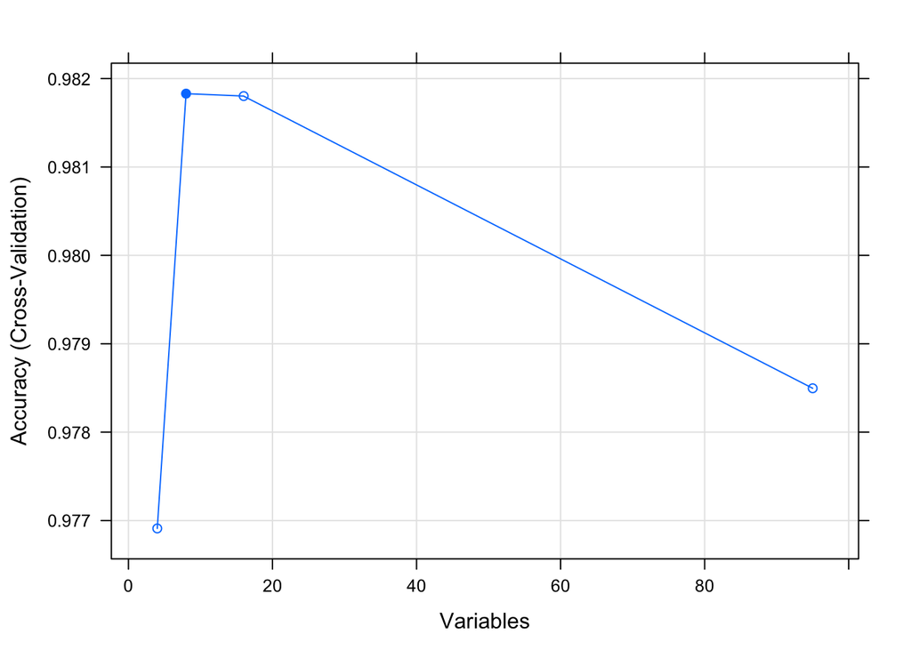

```r
plot(rfe_res, type = c("g", "o"))
```

```r
rfe_res$optVariables
```

```
[1] "neckcircumference"     "neckcircumferencebase" "hipbreadthsitting"
[4] "biacromialbreadth"     "handcircumference"     "shouldercircumference"
[7] "wristcircumference"    "handbreadth"
```

# 4 변수 선택 적용 예측모형

전체 변수를 예측모형에 사용하는 대신 **재귀 변수 제거법**(Recursive Feature Elimination)을 사용해서 훨씬 속도가 빠르게 예측모형을 구축해낸다.

```r
library(tidymodels)
library(rsample)
library(parsnip)

Xy_rfe_df <- Xy_df %>%
  select(c("gender", rfe_res$optVariables))

# 데이터 분할: 훈련/시험
basetable_split <- initial_split(Xy_rfe_df, props = 7/10)

train_dat <- training(basetable_split)
test_dat  <- testing(basetable_split)

# 예측모형 적합
rfe_rf <- rand_forest(trees = 1000, mode = "classification") %>%
  set_engine("ranger", seed = 63233) %>%
  fit(gender ~ ., data = train_dat)

# 예측모형 성능평가
rfe_rf_prob  <- predict(rfe_rf, test_dat, type="prob")
rfe_rf_class <- ifelse(rfe_rf_prob[,2] > .68, "Male", "Female") %>% as.factor()

caret::confusionMatrix(rfe_rf_class, test_dat$gender)
```

```
Confusion Matrix and Statistics

          Reference
Prediction Female Male
    Female     44    3
    Male        0  104

               Accuracy : 0.9801
                 95% CI : (0.943, 0.9959)
    No Information Rate : 0.7086
    P-Value [Acc > NIR] : <2e-16

                  Kappa : 0.9528
 Mcnemar's Test P-Value : 0.2482

            Sensitivity : 1.0000
            Specificity : 0.9720
         Pos Pred Value : 0.9362
         Neg Pred Value : 1.0000
             Prevalence : 0.2914
         Detection Rate : 0.2914
   Detection Prevalence : 0.3113
      Balanced Accuracy : 0.9860

       'Positive' Class : Female
```

# 5 실전 변수 선택 적용 예측모형

```r
## Random Forest
rfe_rf_control <- rfeControl(functions = rfFuncs, method="cv", number=10)
rfe_rf_res <- rfe(x = Xy_df[, -1], y = Xy_df$gender, sizes = 2^(2:4), rfeControl = rfe_rf_control)

## SVM
rfe_svm_control <- rfeControl(functions = svmFuncs, method="cv", number=10)
rfe_svm_res <- rfe(x = Xy_df[, -1], y = Xy_df$gender, sizes = 2^(2:4), rfeControl = rfe_svm_control)
```

[^1]: [Shirin’s playgRound, (15 January 2017), “Feature Selection in Machine Learning (Breast Cancer Datasets)”](https://shiring.github.io/machine_learning/2017/01/15/rfe_ga_post)
[^2]: [Manish Pathak (March 7th, 2018), “Feature Selection in R with the Boruta R Package”](https://www.datacamp.com/community/tutorials/feature-selection-R-boruta)
[^3]: [MKJJO (January 4, 2019), “보루타 알고리즘을 통한 변수선택”](https://mkjjo.github.io/python/2019/01/04/boruta.html)
[^4]: [Kyriakos Chatzidimitriou (23 November, 2017), “Recursive Feature Elimination”](http://ml-tutorials.kyrcha.info/rfe.html)